# Uso de Internet y Confianza Social en Europa

2026-09-01

## Objetivo

Analizar la evolución de la relación entre el **uso de internet** y la **confianza social** en Europa (2016-2023), a partir de datos de la European Social Survey (ESS), para generar evidencia contextual que informe decisiones de diseño de producto sensibles a la confianza del usuario.

## Datos y método

- **Fuente:** European Social Survey, Rondas 8, 9, 10 y 11
- **N total:** 181633 observaciones
- **Índice de confianza social:** promedio de 3 ítems de confianza interpersonal (α de Cronbach = 0.79)
- **Decisión metodológica clave:** en la Ronda 10 se excluyeron los países con modo de auto-completado (por la pandemia), para mantener consistencia metodológica

## Indicadores principales por ronda

| Ronda | N | Uso internet (1-5) | Confianza (0-10) |
| --- | --- | --- | --- |
| 8 | 44387 | 3.86 | 5.43 |
| 9 | 49519 | 3.90 | 5.22 |
| 10 | 37611 | 4.06 | 5.12 |
| 11 | 50116 | 4.20 | 5.17 |

## Hallazgo principal

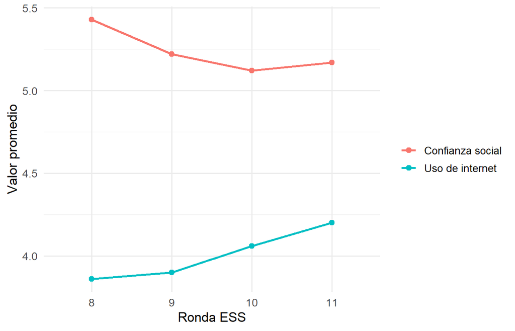

## Interpretación

**Conclusión:** la relación positiva entre uso individual de internet y confianza (a nivel transversal) no implica que más digitalización agregada genere más confianza social en el tiempo.

## Implicancias para diseño de producto

- La confianza social de un país es más **estructural** (cultural) que **coyuntural** (nivel de digitalización)
- Países con confianza social baja probablemente necesiten:
  - Verificación de identidad más explícita
  - Mayor transparencia en el uso de datos
  - Onboarding progresivo que genere confianza paso a paso
- Esto aplica independientemente de cuán digitalizada esté su población

## Limitaciones

- Relaciones **asociativas**, no causales
- Ronda 10 excluye países con auto-completado (menor cobertura de países)
- El dashboard interactivo completo está disponible en: `https://asll-lab.github.io/ess-internet-trust-dashboard/dashboard/dashboard.html`